# Exercício 8 - SCC0270 Redes Neurais e Aprendizado Profundo

**NOME:** Matheus Aparecido do Carmo Alves **- NºUSP:** 9791114

## Exercício (parte 1)

Com base no conjunto de dados MNIST:

1. Junte TODAS as imagens em um único conjunto. O próximo item deste exercício deve ser executado para 10%, 20%, 30%, 40%, 50%, 60%, 70%, 80%, 90% e 100% da quantidade total de imagens. Em outras palavras, considerando todas as imagens, deve ser separado 10%para executar o método de validação escolhido. Os conjuntos de treino e de teste devem ser separados a partir dos 10% selecionados anteriormente. Esse mesmo procedimento (de separação dos dados) deve ser realizado para cada uma das proporções descritas anteriormente.
2. Implemente uma Rede Neural Convolutiva para a classificação das imagens de cada uma das proporções citadas. Defina uma arquitetura de RNC que será usada em todas as proporções e utilize um método de validação que proporcione uma validação justa e coerente ao modelo. Plote em um mesmo gráfico a acurácia alcançada pelo modelo nas etapas de treino e de teste em cada proporção. O principal objetivo desta atividade é analisar a evolução do comportamento da RNC com diferentes quantidades de imagens.

**A. IMPLEMENTAÇÃO**

Primeiramente, iremos carregar o dataset MNIST.

```python
from mnist import MNIST
def load_mnist():
    mndata = MNIST('mnist_dataset')

    X_train, y_train = mndata.load_training()
    X_test, y_test = mndata.load_testing()

    X, y = [], []
    for i in range(len(X_train)):
        X.append(X_train[i])
        y.append(y_train[i])
    for i in range(len(X_test)):
        X.append(X_test[i])
        y.append(y_test[i])

    return X, y

X,y = load_mnist()
```

Com os dados carregados, partiremos para o pré-processamento.

Nesta etapa, será aplicada a normalização via Média e Desvio padrão.

```python
import numpy as np
import os
import pickle
from sklearn.preprocessing import StandardScaler
import tensorflow.keras as keras

if os.path.exists("mnist_dataset/X.Pickle"):
    with open("mnist_dataset/X.Pickle","rb") as file:
        X_cnn = pickle.load(file)
        y_cnn = np.array(keras.utils.to_categorical(y))
else:
    # scaling the data via mean and std dev scaler
    scaler = StandardScaler()
    X_scaled = scaler.fit_transform(X,y)

    # reshaping for cnn
    X_cnn = X_scaled.reshape(-1, 28,28, 1)
    y_cnn = np.array(keras.utils.to_categorical(y))

    # saving the cnn processed dataset
    with open("mnist_dataset/X.Pickle","wb") as file:
        pickle.dump(X_cnn,file)
```

De maneira direta, a arquitetura/modelo da RNC que será utilizada para este exercício segue:

[figure not shown]

Para mais detalhes sobre a escolha dessa implementação, sugere-se a leitura do [Projeto 1](https://github.com/Micanga/scc0270_redes_neurais/blob/master/project_1/9791114_Projeto_1.pdf) desenvolvido para esta mesma disciplina.

Assim, iremos criar um inicializador para nossa rede neural.

```python
def init_cnn(n_layers, num_classes, filter_sizes, alpha,\
input_shape=(28,28,1), kernel_size=(3,3), pool_size=(2,2), dropout=False, dropout_rate=0.3):
    model = keras.Sequential()

    # Input Layer
    model.add(keras.layers.Conv2D(filters=filter_sizes[0], kernel_size=kernel_size,activation='linear',\
                                input_shape=input_shape,padding='same'))
    model.add(keras.layers.LeakyReLU(alpha=alpha))
    model.add(keras.layers.MaxPooling2D(pool_size,padding='same'))
    if dropout:
        if isinstance(dropout_rate, list):
            model.add(keras.layers.Dropout(dropout_rate[0]))
        else:
            model.add(keras.layers.Dropout(dropout_rate))

    # Hidden Layers
    for i in range(1,n_layers-1):
        model.add(keras.layers.Conv2D(filter_sizes[i], kernel_size, activation='linear',padding='same'))
        model.add(keras.layers.LeakyReLU(alpha=alpha))
        model.add(keras.layers.MaxPooling2D(pool_size,padding='same'))
        if dropout:
            if isinstance(dropout_rate, list):
                model.add(keras.layers.Dropout(dropout_rate[i]))
            else:
                model.add(keras.layers.Dropout(dropout_rate))

    # Output Layer
    model.add(keras.layers.Flatten())
    model.add(keras.layers.Dense(filter_sizes[-1], activation='linear'))
    model.add(keras.layers.LeakyReLU(alpha=alpha))
    if dropout:
        if isinstance(dropout_rate, list):
            model.add(keras.layers.Dropout(dropout_rate[-1]))
        else:
            model.add(keras.layers.Dropout(dropout_rate))
    model.add(keras.layers.Dense(num_classes, activation='softmax'))

    # Compiling
    model.compile(loss=keras.losses.categorical_crossentropy,\
     optimizer=keras.optimizers.Adam(),metrics=['accuracy'])

    # Returning
    return model
```

Com o iniciaizador criado, inicia-se o processo de coleta de dados.

**B. COLETA DE DADOS**

Para realização desta etapa, primeiro é necessário se definir o conjunto de teste e o conjunto de treino.

```python
from sklearn.model_selection import train_test_split

X_cnn_train, X_cnn_test, y_cnn_train, y_cnn_test =\
    train_test_split(X_cnn, y_cnn, test_size=0.15, random_state=1)
```

Definidos estes dois conjuntos, serão executados o treinamento e o teste da nossa arquitetura de acordo com a metodologia definida para o exercício.

O código abaixo implementa esta metodologia e coleta os resultados.

```python
result = {'test_score':[],'train_score':[]}
for percentage in [0.1, 0.2, 0.3, 0.4, 0.5, 0.6, 0.7, 0.8, 0.9, 1.0]:
    print('=====\nTraining with',percentage*100,'% of the train set\n=====')
    cnn = init_cnn(4, 10, [32,64,128,128], 0.1,\
        input_shape=(28,28,1), kernel_size=(3,3), pool_size=(2,2),\
         dropout=True,dropout_rate=[0.25,0.25,0.4,0.3])

    cnn_history = cnn.fit(\
        X_cnn_train[0:int(percentage*len(X_cnn_train)),:],\
        y_cnn_train[0:int(percentage*len(X_cnn_train)),:], \
        batch_size=64, epochs=1,\
        validation_data=(X_cnn_test, y_cnn_test))

    result['train_score'].append(cnn_history.history['accuracy'])
    result['test_score'].append(cnn_history.history['val_accuracy'])
```

```
=====
Training with 10.0 % of the train set
=====
Train on 5950 samples, validate on 10500 samples
=====
Training with 20.0 % of the train set
=====
Train on 11900 samples, validate on 10500 samples
=====
Training with 30.0 % of the train set
=====
Train on 17850 samples, validate on 10500 samples
=====
Training with 40.0 % of the train set
=====
Train on 23800 samples, validate on 10500 samples
=====
Training with 50.0 % of the train set
=====
Train on 29750 samples, validate on 10500 samples
=====
Training with 60.0 % of the train set
=====
Train on 35700 samples, validate on 10500 samples
=====
Training with 70.0 % of the train set
=====
Train on 41650 samples, validate on 10500 samples
=====
Training with 80.0 % of the train set
=====
Train on 47600 samples, validate on 10500 samples
=====
Training with 90.0 % of the train set
=====
Train on 53550 samples, validate on 10500 samples
=====
Training with 100.0 % of the train set
=====
Train on 59500 samples, validate on 10500 samples
```

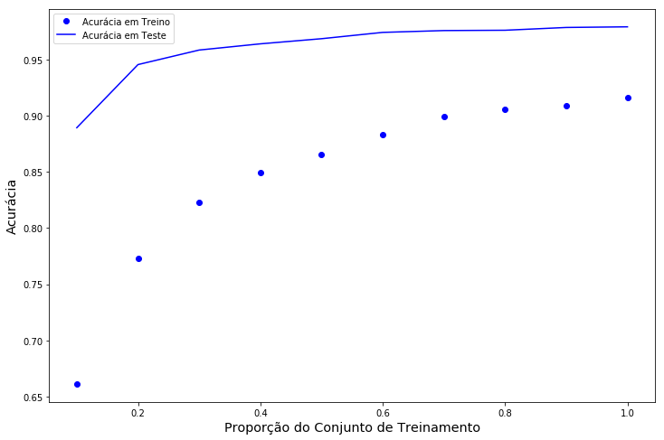

```python
train_acc = np.array([ r[0] for r in result['train_score'] ])
test_acc = np.array([ r[0] for r in result['test_score'] ])
epochs = np.arange(0.1,1.1,0.1)

import matplotlib.pyplot as plt
plt.figure(figsize=(12,8));
plt.plot(epochs, train_acc, 'bo', label='Acurácia em Treino')
plt.plot(epochs, test_acc, 'b', label='Acurácia em Teste')
plt.xlabel('Proporção do Conjunto de Treinamento',fontsize='x-large')
plt.ylabel('Acurácia',fontsize='x-large')
plt.legend()
plt.show()
```

## Exercício (parte 2)

1. Analise os resultados obtidos. Existiu baixa generalização dos dado padrão aprendido? Se sim, em qual(is) proporção(ões)? Na sua opinião, porque isso ocorreu?

**RESPOSTA:**

Sim, existiu uma baixa generalização sobre o padrão apredendido.

Analisando a evolução da acurácia durante o processo, é possível notar que com 30% ou mais da quantidade de dados definidos para treino (i.e., com um conjunto de exemplos igual ou maior à 17850) alcança-se uma acurácia próxima ou maior a 95% durante as fases de teste sobre o conjunto. Contudo, a acurácia associada a fase de treino é, consideravelmente, menor e não suficiente para a generalização do conjunto de dados.

Isso ocorreu, possívelmente, pelo fato do conjunto de treino buscar aprimorar a generalização (quanto a representação das classes disponíveis) de maneira iterativa (enquanto atualiza os pesos da rede), aumentando o erro total, mas reduzindo o erro de predição final.